# RNAseq analysis with on DESeq2

Yifei Wan

May/6/2018

# RNAseq analysis with on DESeq2

## Input data

- Prepare data from matrix

```r
library('pasilla')
pascount <- system.file('extdata', 'pasilla_gene_counts.tsv', package='pasilla', mustWork=TRUE)
pasmeta <- system.file('extdata', 'pasilla_sample_annotation.csv', package='pasilla', mustWork=TRUE)
rawdata <- as.matrix(read.csv2(pascount,sep='\t',row.names='gene_id'))
coldata <- read.csv2(pasmeta, row.names=1, sep = ',')
#coldata <- coldata[,c('condition','type')] ## test code

temprowname <- rownames(coldata)
coldata <- data.frame(coldata$condition)
colnames(coldata) <- 'condition'
rownames(coldata) <- temprowname
```

The rawdata records the count of reads of each RNA. The coldata is the meta data which includes the experiment design and sequence method.

Let’s examine the count data and coladata to ensure that they are what we want:

```r
head(rawdata)
```

```
##             untreated1 untreated2 untreated3 untreated4 treated1 treated2
## FBgn0000003          0          0          0          0        0        0
## FBgn0000008         92        161         76         70      140       88
## FBgn0000014          5          1          0          0        4        0
## FBgn0000015          0          2          1          2        1        0
## FBgn0000017       4664       8714       3564       3150     6205     3072
## FBgn0000018        583        761        245        310      722      299
##             treated3
## FBgn0000003        1
## FBgn0000008       70
## FBgn0000014        0
## FBgn0000015        0
## FBgn0000017     3334
## FBgn0000018      308
```

```r
head(coldata)
```

```
##              condition
## treated1fb     treated
## treated2fb     treated
## treated3fb     treated
## untreated1fb untreated
## untreated2fb untreated
## untreated3fb untreated
```

The DESeq2 requires the columns of count matrix and the rows of coldata are in same order. Unfortunately, above output appears that the order of columns in our data is not consistant. We must rearrange it. Furthermore, the rownames of coldata include additional letters: “fb” which should be chopped off.

```r
rownames(coldata) <- sub('fb', '', rownames(coldata)) ## chop off the 'fb'
all(rownames(coldata) %in% colnames(rawdata))
```

```
## [1] TRUE
```

```r
all(colnames(rawdata) == rownames(coldata)) ## check the order of names
```

```
## [1] FALSE
```

```r
rawdata <- rawdata[, rownames(coldata)]
all(colnames(rawdata) == rownames(coldata)) ## double check the order
```

```
## [1] TRUE
```

```r
# not run (test code):
# temprowname <- sub('fb', '', temprowname)
# all(temprowname %in% colnames(rawdata))
# all(colnames(rawdata) == temprowname) ## check the order of names
# rownames(coldata) <- temprowname
# rawdata <- rawdata[, rownames(coldata)]
# all(colnames(rawdata) == rownames(coldata))
```

In DESeq2, all information should be stored as an object `DESeqDataSet`. It needs count matrix and coldata which we already have. Let’s start to make a `DESeqDataSet`:

```r
library(DESeq2)
dds <- DESeqDataSetFromMatrix(countData = rawdata, colData = coldata, design = ~ condition)
dds
```

```
## class: DESeqDataSet
## dim: 14599 7
## metadata(1): version
## assays(1): counts
## rownames(14599): FBgn0000003 FBgn0000008 ... FBgn0261574
##   FBgn0261575
## rowData names(0):
## colnames(7): treated1 treated2 ... untreated3 untreated4
## colData names(1): condition
```

- Prepare data from HTSeq count

We are able to input data from HTSeq count file also. The pathway (directory) of HTSeq file should be pointed to a variable. Then, the function DESeqDataSetFromHTSeqCount would be applied to extract data from HTSeq file. But just for the demonstration purposes, we stll use the pasilla package as an example.

```r
directory <- system.file("extdata", package="pasilla", mustWork=TRUE)
sampleFiles <- grep("treated",list.files(directory),value=TRUE)
sampleCondition <- sub("(.*treated).*","\\1",sampleFiles)
sampleTable <- data.frame(sampleName = sampleFiles, fileName = sampleFiles, condition = sampleCondition)
ddsHTSeq <- DESeqDataSetFromHTSeqCount(sampleTable = sampleTable, directory = directory, design= ~ condition)
ddsHTSeq
```

```
## class: DESeqDataSet
## dim: 70463 7
## metadata(1): version
## assays(1): counts
## rownames(70463): FBgn0000003:001 FBgn0000008:001 ...
##   FBgn0261575:001 FBgn0261575:002
## rowData names(0):
## colnames(7): treated1fb.txt treated2fb.txt ... untreated3fb.txt
##   untreated4fb.txt
## colData names(1): condition
```

## Pre-filter

Pre-filter can remove the low count data from DESeqDataSet. There are two reasons to do so: + Reduce the memory size of DESeqDataSet; + increase the speed of transformation and testing functions.

This is not a necessary step. Since the DESeq provides a more strict approch to filter low count data: independent filtering. But we can introduce the `HTSFilter` package which implements a filtering procedure for replicated transcriptome sequencing data based on a global Jaccard similarity index in order to identify genes with low, constant levels of expression across one or more experimental conditions. The independent filtering should be turned off while we use the `HTSFilter` to avoid the over-filtering. The best threshold would be shown on the image.

```r
library(HTSFilter)
dds <- estimateSizeFactors(dds)
dds <- estimateDispersions(dds)
## The argument `s.len` indicates how many threshold should be tried.
filter <- HTSFilter(dds, s.len = 50, normalization = 'DESeq')$filter
```

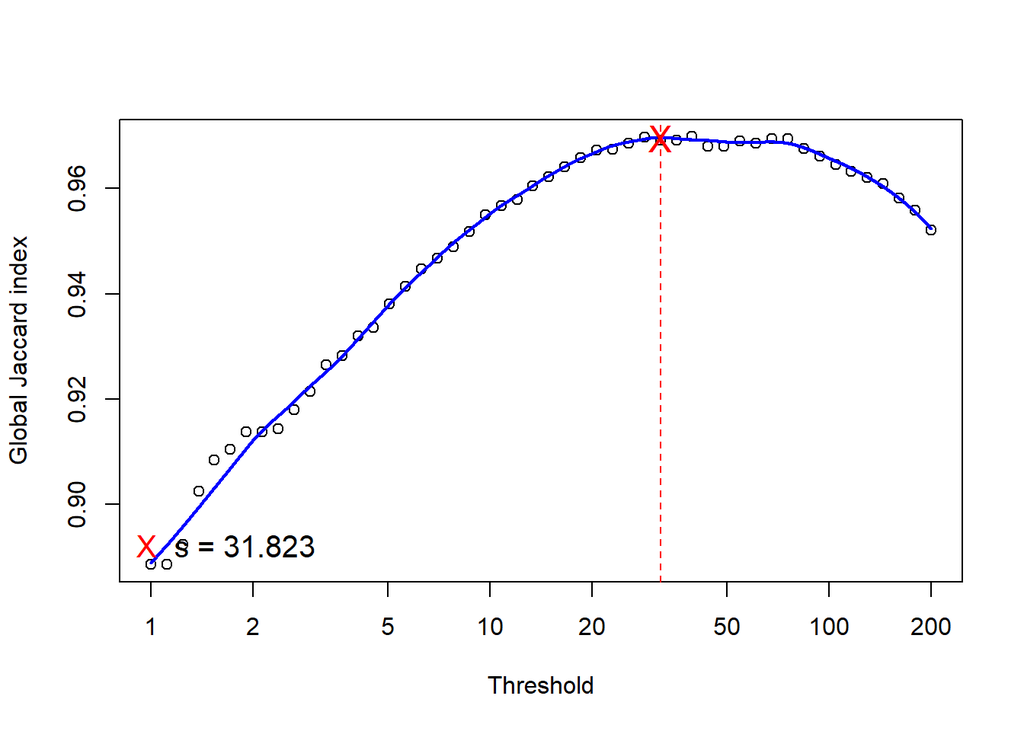

```r
class(filter)
```

```
## [1] "DESeqDataSet"
## attr(,"package")
## [1] "DESeq2"
```

```r
filter
```

```
## class: DESeqDataSet
## dim: 7477 7
## metadata(1): version
## assays(2): counts mu
## rownames(7477): FBgn0000008 FBgn0000017 ... FBgn0261573
##   FBgn0261574
## rowData names(9): baseMean baseVar ... dispOutlier dispMAP
## colnames(7): treated1 treated2 ... untreated3 untreated4
## colData names(2): condition sizeFactor
```

```r
head(counts(filter))
```

```
##             treated1 treated2 treated3 untreated1 untreated2 untreated3
## FBgn0000008      140       88       70         92        161         76
## FBgn0000017     6205     3072     3334       4664       8714       3564
## FBgn0000018      722      299      308        583        761        245
## FBgn0000032     1698      696      757       1446       1713        615
## FBgn0000042   127363    76099    83164     101664     120163      45880
## FBgn0000043    56048    31421    34344      33402      41118      16007
##             untreated4
## FBgn0000008         70
## FBgn0000017       3150
## FBgn0000018        310
## FBgn0000032        672
## FBgn0000042      53201
## FBgn0000043      18360
```

```r
head(counts(dds))
```

```
##             treated1 treated2 treated3 untreated1 untreated2 untreated3
## FBgn0000003        0        0        1          0          0          0
## FBgn0000008      140       88       70         92        161         76
## FBgn0000014        4        0        0          5          1          0
## FBgn0000015        1        0        0          0          2          1
## FBgn0000017     6205     3072     3334       4664       8714       3564
## FBgn0000018      722      299      308        583        761        245
##             untreated4
## FBgn0000003          0
## FBgn0000008         70
## FBgn0000014          0
## FBgn0000015          2
## FBgn0000017       3150
## FBgn0000018        310
```

## Differential Expression analysis

We can strat to analyze the DE based on filtered data. Do not forget to turn off the independent filter.

```r
filter <- DESeq(filter)
```

```
## found already estimated dispersions, replacing these
```

```r
de <- results(filter, independentFiltering = F, contrast=c("condition","treated","untreated"))
de
```

```
## log2 fold change (MLE): condition treated vs untreated
## Wald test p-value: condition treated vs untreated
## DataFrame with 7477 rows and 6 columns
##                baseMean log2FoldChange     lfcSE         stat     pvalue
##               <numeric>      <numeric> <numeric>    <numeric>  <numeric>
## FBgn0000008    95.14408    0.002046875 0.2281486  0.008971674 0.99284174
## FBgn0000017  4352.59290   -0.240022903 0.1246234 -1.925986070 0.05410611
## FBgn0000018   418.61493   -0.104799292 0.1484342 -0.706032188 0.48016812
## FBgn0000032   989.73003   -0.091904692 0.1474373 -0.623347563 0.53305615
## FBgn0000042 82207.72464    0.314524265 0.1395206  2.254321633 0.02417594
## ...                 ...            ...       ...          ...        ...
## FBgn0261564   1158.3701    -0.08776116 0.1065367  -0.82376485 0.41007318
## FBgn0261565    619.6578    -0.29677715 0.1411433  -2.10266598 0.03549498
## FBgn0261570   3208.3845     0.29542754 0.1256913   2.35042173 0.01875215
## FBgn0261573   2240.9840     0.01260455 0.1108148   0.11374430 0.90944049
## FBgn0261574   4857.7427     0.01525493 0.1938127   0.07870965 0.93726357
##                  padj
##             <numeric>
## FBgn0000008 0.9967722
## FBgn0000017 0.2541189
## FBgn0000018 0.8039167
## FBgn0000032 0.8319648
## FBgn0000042 0.1477836
## ...               ...
## FBgn0261564 0.7609642
## FBgn0261565 0.1930737
## FBgn0261570 0.1234602
## FBgn0261573 0.9786213
## FBgn0261574 0.9873161
```

The `constract` specifies what comparison to extract from the object to build a results table. It’s a vector with exactly three elements: the name of a factor in the design formula, the name of the numerator level for the fold change, and the name of the denominator level for the fold change.

We can re-order the p-values:

```r
resOrdered <- de[order(de$pvalue),]
summary(resOrdered)
```

```
##
## out of 7477 with nonzero total read count
## adjusted p-value < 0.1
## LFC > 0 (up)     : 513, 6.9%
## LFC < 0 (down)   : 553, 7.4%
## outliers [1]     : 1, 0.013%
## low counts [2]   : 0, 0%
## (mean count < 0)
## [1] see 'cooksCutoff' argument of ?results
## [2] see 'independentFiltering' argument of ?results
```

How many RNA with p-values less than 0.1?

```r
sum(resOrdered$padj < 0.1, na.rm=TRUE)
```

```
## [1] 1066
```

## Plot the MA-plot

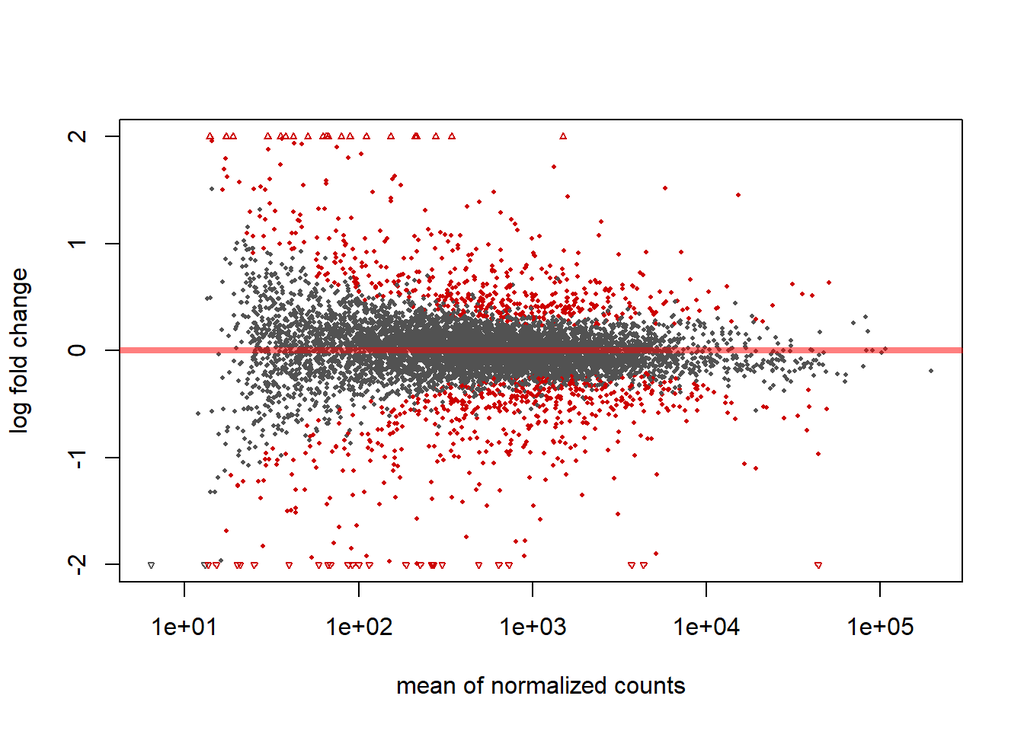

```r
plotMA(de, ylim=c(-2,2))
```

```r
resultsNames(filter)
```

```
## [1] "Intercept"                      "condition_untreated_vs_treated"
```

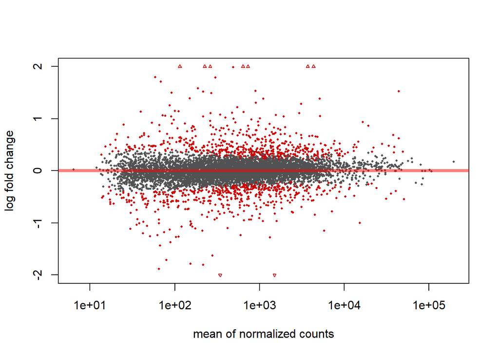

```r
resLFC <- lfcShrink(filter, coef="condition_untreated_vs_treated", type="normal")
plotMA(resLFC, ylim=c(-2,2))
```

The points which we are interested in can be located by:

```r
#idx <- identify(de$baseMean, de$log2FoldChange)
#rownames(de)[idx]
```